# BellaBeat Case Study Report

Matthew Yusuf

2025-09-12

This report outlines the analysis of smart device fitness data. The goal is to provide the BellaBeat leadership and marketing analytics team with valuable insights into consumer usage and offer recommendations to further guide marketing strategies

## Phase 1: Act

### Business Task

Analyze smart device fitness data to gain insights into how the general public uses non-BellaBeat smart devices. The goal is to provide recommendations that will assist in guiding BellaBeat’s marketing strategies and guide the company towards new growth opportunities.

### Stakeholders

The primary stakeholders for this project are Urška Sršen, co-founder and Chief Creative Officer, other members of the BellaBeat executive team, and the marketing analytics team.

## Phase 2: Prepare

### The Data Source

The public dataset is titled: “FitBit Fitness Tracker Data” on Kaggle. It was made available through a survey on Amazon Mechanical Turk and contains data on 30 FitBit users.

## Phase 3: Process

### Aggregate and Merge Data Frames

```r
## aggregate the sleep and hourly steps data to represent daily totals
daily_sleep_total <- minute_sleep %>%
  group_by(id, sleep_date) %>%
  summarize(total_minutes_asleep = sum(value), .groups = "drop")
daily_steps_total <- hourly_steps %>%
  group_by(id, date = as_date(activity_hour)) %>%
  summarize(total_steps = sum(step_total), .groups = "drop")



## merge datasets
combined_data <- daily_activity %>%
  inner_join(daily_sleep_total, by = c("id", "activity_date" = "sleep_date"))
combined_data <- combined_data %>%
  inner_join(daily_steps_total, by = c("id" = "id", "activity_date" = "date"))
```

## Phase 4: Analyze

### Descriptive Statistics

```r
### rename total_steps.y column and then calculate average daily steps, calories burned, and minutes slept
combined_data <- combined_data %>%
  rename(hourly_total_steps = total_steps.y)

combined_data %>%
  summarize(
    average_daily_steps = mean(hourly_total_steps),
    average_calories_burned = mean(calories),
    average_sleep_minutes = mean(total_minutes_asleep)
  )
```

```
## # A tibble: 1 × 3
##   average_daily_steps average_calories_burned average_sleep_minutes
##                 <dbl>                   <dbl>                 <dbl>
## 1               7872.                   2335.                  468.
```

### Trends by Day of the Week

```r
### add day_of_week column
combined_data <- combined_data %>%
  mutate(day_of_week = wday(activity_date, label = TRUE))

### calculate average steps by the weekday
daily_steps_by_day <- combined_data %>%
  group_by(day_of_week) %>%
  summarize(
    average_steps = mean(hourly_total_steps),
    average_calories = mean(calories)
  )
```

We added a day_of_week column to the combined dataset so that we could easily calculate the descriptive statistics by each different day of the week.

| Day of Week | Average Steps | Average Calories |
| --- | --- | --- |
| Sunday | 7,243.219 | 2,290.000 |
| Monday | 7,764.966 | 2,292.966 |
| Tuesday | 6,698.276 | 2,025.724 |
| Wednesday | 9,222.091 | 2,629.455 |
| Thursday | 8,569.217 | 2,499.348 |
| Friday | 8,007.379 | 2,360.207 |
| Saturday | 8,086.629 | 2,353.714 |

As you can see, Wednesday and Thursday are the most active days for the users we studied. As a result, these are also the days that users burned the most calories. This suggests that users are more engaged with their fitness goals in the middle of the work week. The days with lowest average steps are Sunday and Tuesday, posing a potential marketing opportunity for BellaBeat.

### User Segmentation

```r
## segment users by activity level: categorize users by their average daily steps
### create a segmented user column
user_segments <- combined_data %>%
  group_by(id) %>%
  summarize(average_steps = mean(hourly_total_steps)) %>%
  ungroup() %>%
  mutate(
    user_type = case_when(
      average_steps < 5000 ~ "Not Active",
      average_steps >= 5000 & average_steps < 7500 ~ "Lightly Active",
      average_steps >= 7500 & average_steps < 10000 ~ "Fairly Active",
      average_steps >= 10000 ~ "Very Active"
    )
  )
```

We created different categories to segment the users into different levels of fitness activity. For example, those with an average of less than 5,000 steps per day are considered “Not Active,” between 5,000 and 7,500 average steps are considered “Lightly Active,” between 7,500 and 10,000 steps are considred “Fairly Active.” Lastly, users that were averaging more than 10,000 steps per day are to be considered “Very Active.”

### Relationship between Total Steps and Calories Burned

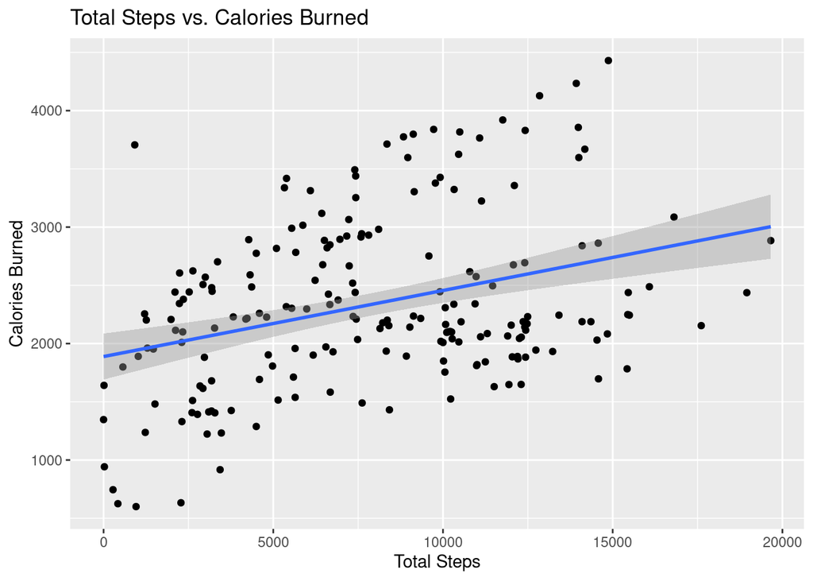

```r
ggplot(data = combined_data, aes(x = hourly_total_steps, y = calories)) +
  geom_point() +
  geom_smooth(method = "lm") +
  labs(title = "Total Steps vs. Calories Burned",
       x = "Total Steps",
       y = "Calories Burned")
```

Intuitively, we would think that with the more steps that a user would walk on a daily basis, then they would also burn more calories. This trend is confirmed with this scatter plot, as demonstrated by the trendline as well. Note that there are a number of outliers that may be the result of non-step activities or high-intensity interval training. These outliers also present BellaBeat with a prime opportunity to guide market strategies towards focusing beyond just daily steps.

## Phase 5: Share

### Key Findings and Recommendations

Based on our analysis, we recommend launching a middle-of-the-week promotion to capitalize on the higher user usage on Wednesdays and Thursdays. This could be like in-app challenges, targeted emails, or push-notifications to encourage users to maintain their fitness level. We should also emphasize the diversity of our products, focusing on how we track several non-step activities like yoga, sleep, any cycling. Lastly, we need to create content and campaigns that will help users on their least active days like Sundays and Tuesdays. For example, we could offer lower-intensity fitness routines and guided meditations on Sundays as some sort of “mental reset” before the upcoming work week.

## Phase 6: Act

### Conclusion and Next Steps

Our analysis of non-BellaBeat smart device usage provided us with several valuable insights into some of the habits of a small sample size of users. These findings include that fitness activity is highest in the middle of the week, engagement is inconsistent during the weekend. and numerous users also partake in other non-step-based physical activities. These new discoveries confirm the untapped potential that we have, as a company, to expand our market by targeting these user habits. The data-driven recommendations offer our leadership and marketing team with optimal strategies to enhance user engagement and enrich growth.

Unfortunately, our current analysis is still relatively limited by the comparatively smaller sample size of 33 users. We would likely need to expand the dataset in order to provide more reliable results. We will suggest our team to implement a new survey to collect more data, and even from a wider demographic so that we can create and understand more diverse user segments. In the end, the marketing team should use the insights from this analysis to develop new marketing campaigns.